# Chap1

# Code following the book “Phylogenetic Comparative Methods in R - Liam J. Revell and Luke J. Harmon, 2022”

## Chapter1

```r
library(ape)
library(phytools)
library(readr)
library(geiger)
```

#### Operations with simple newick text string

Reading a simple Newick text string: “is a simple way to encode a phylogenetic tree using a series of nested parentheses.More closely nested species are more closely related. For instance, the simple Newick tree ((chimp,human),gorilla); tells us that the operational taxa chimp and human aremore closely related to each other than either is to gorilla. There are other ways that phylogenetic trees can be represented in machine-readable text, but the Newick string is by far the most common.”

```r
text.string<-
"(((((Robin,Iguana),((((Cow,Whale),Pig),Bat),
(Lemur,Human))),Coelacanth),Goldfish),Shark);"
vert.tree<-read.tree(text=text.string)
```

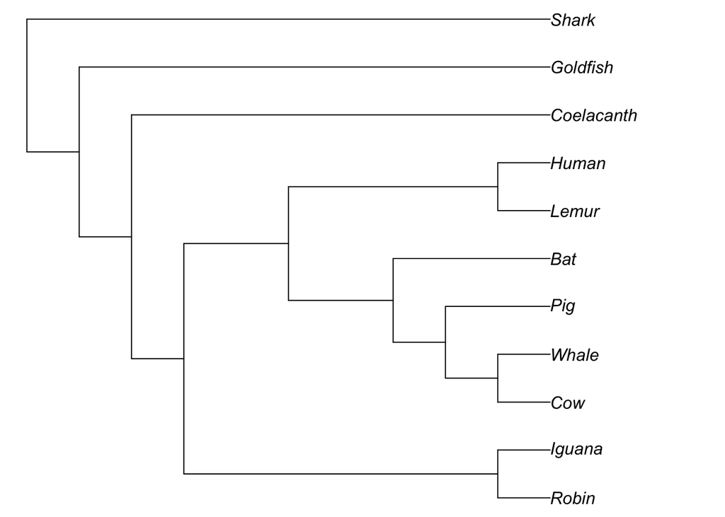

```r
#ploting the tree

plot(vert.tree,no.margin=TRUE)
```

```r
#if you wanna see the arguments
#args(plot.phylo)
```

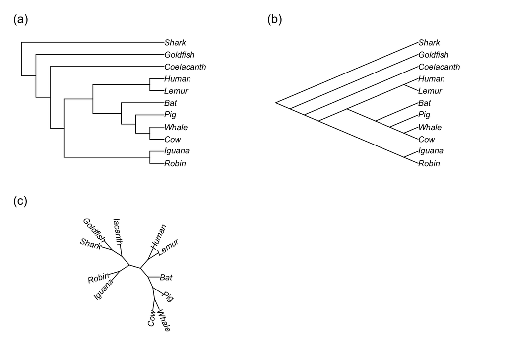

```r
#Plotting the tree with different styles

par(mfrow=c(2,2),mar=c(1.1,1.1,3.1,1.1)) #divide our plotting device into four subplots for a 2 × 2 grid—
#The order of this vector is bottom, left, top, and right—

#plot in (a) using a retangular cladrogram style
plot(vert.tree)
mtext("(a)",line=1,adj=0)

#plot in (b) with a slanted cladogram style
plot(vert.tree,type="cladogram")
mtext("(b)",line=1,adj=0)

#plot in (c) with a unrooted tree syle
plot(unroot(vert.tree),type="unrooted",
lab4ut="axial",x.lim=c(-2,6.5),
y.lim=c(-3,7.5))
mtext("(c)",line=1,adj=0)
```

The “vert.tree” object is a list containing (at least) the following elements: 1. edge: a 20 × 2 (in this case) matrix containing starting and ending indices for the nodes subtending each branch of the phylogeny. By convention, tip nodes (that is, those corresponding to species or operational taxa) are numbered 1 through N for N species, while internal nodes are numbered N +1 (at the root) through N+ the number of internal nodes 2. Nnode: an integer value giving the total number of internal nodes in the tree. 3. tip.label: a character vector of length N containing the labels for all the tips or terminal taxa in the phylogeny.

We can visualize this structure like this:

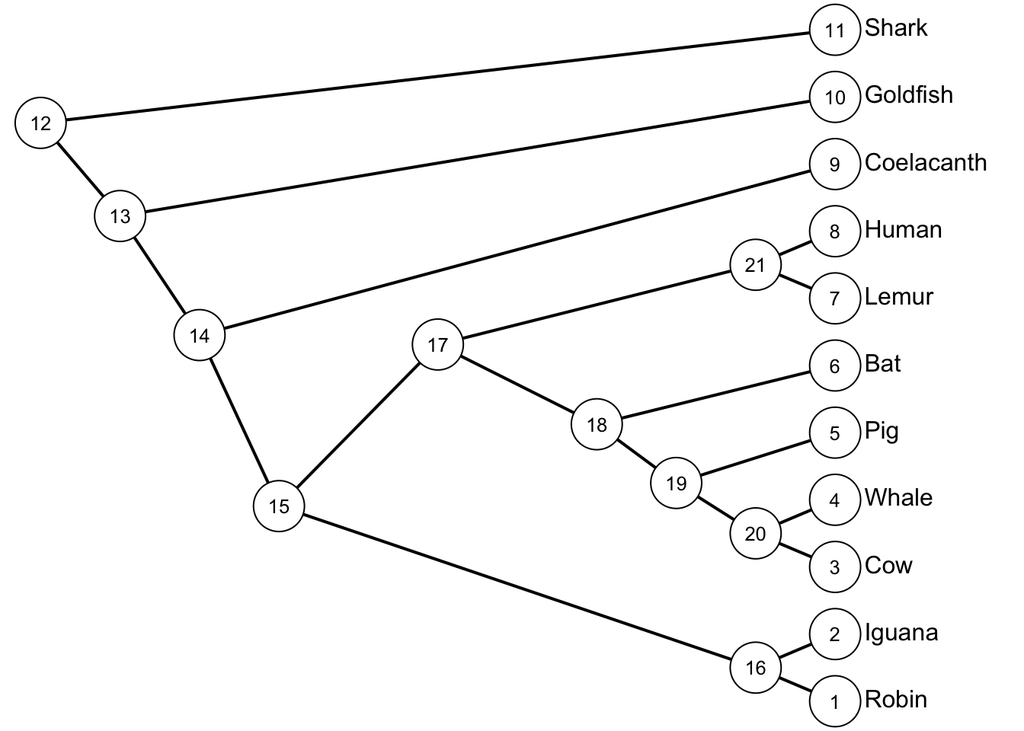

```r
plotTree(vert.tree,offset=1,type="cladogram")
labelnodes(1:(Ntip(vert.tree)+vert.tree$Nnode), 1:(Ntip(vert.tree)+vert.tree$Nnode),interactive=FALSE,cex=0.8)
```

The node numbers are simply the indices from the “phylo” object element edge, which is itself a matrix containing the starting and ending indices for each branch of the phylogeny!

```r
#Save the tree in a file:
write.tree(vert.tree,file="example.tre")
```

```r
#Add arrow in some species and plot in a circular style
plotTree(vert.tree,type="fan",fsize=0.6,lwd=1,ftype="i")

pr.species<-c("Cow","Whale","Coelacanth","Human","Bat")
nodes<-sapply(pr.species,grep,x=vert.tree$tip.label)
nodes #grep matches a character pattern to a vector and returns the positions of the elements of the vector in which that pattern is found.
```

```
##        Cow      Whale Coelacanth      Human        Bat
##          3          4          9          8          6
```

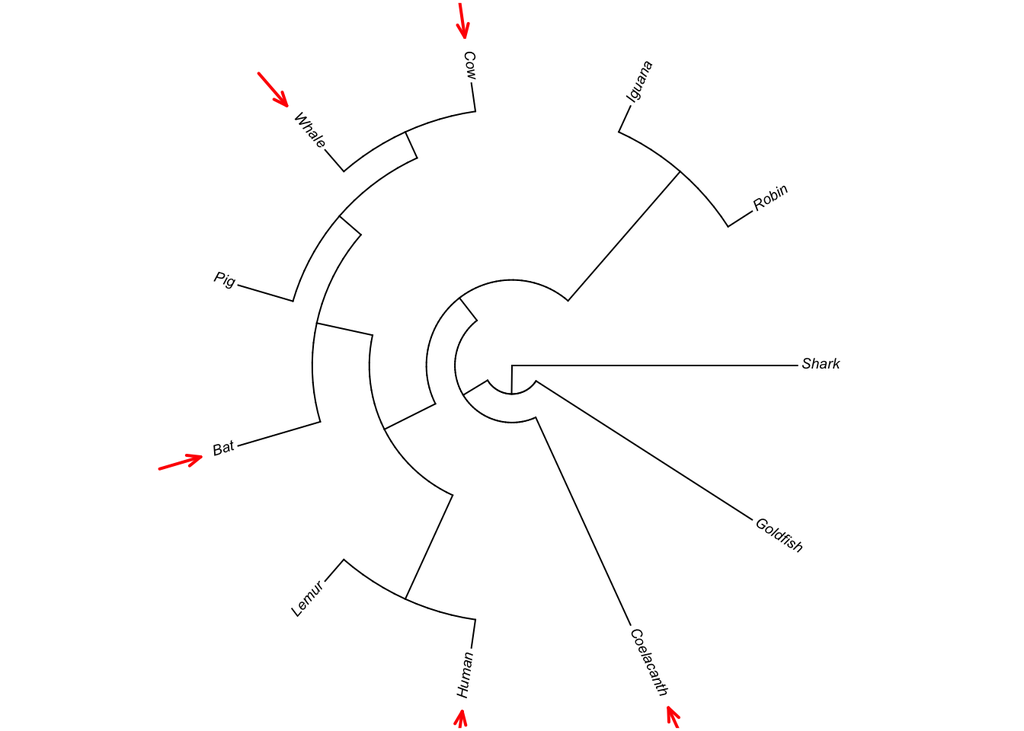

```r
add.arrow(vert.tree,tip=nodes,arrl=0.15,col="red",offset=2)
```

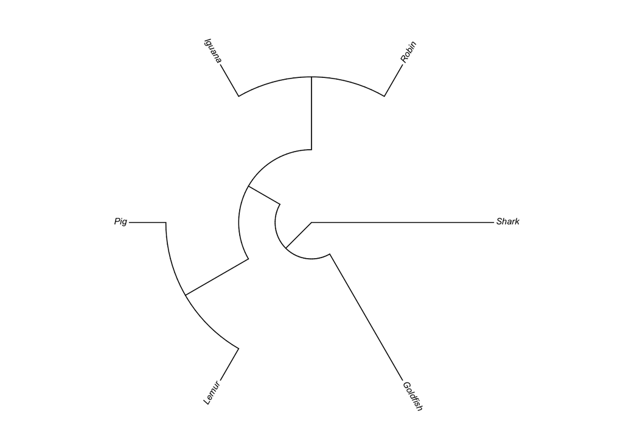

```r
#Now we can prune these species out of the three:
vert.noPR<-drop.tip(vert.tree,pr.species)
plotTree(vert.noPR,type="fan",fsize=0.6,lwd=1,
ftype="i")
```

Now, if we want to extract the clade in which the mammmals are, we should exclude the “Coelacanth””

```r
node<-getMRCA(vert.tree,pr.species[
-which(pr.species%in%c("Coelacanth"))])
node
```

```
## [1] 17
```

And then found the most recent common ancestor (MRCA) of the members of the clade we want to prune (mammalian):

Let’s color it so we can visualize:

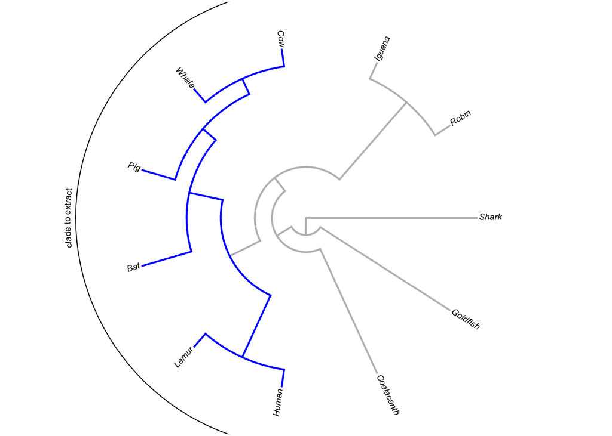

```r
plot(paintSubTree(vert.tree,node,"b","a"),
type="fan",fsize=0.6,lwd=2,
colors=setNames(c("gray","blue"),c("a","b")),
ftype="i")
arc.cladelabels(vert.tree,"clade to extract",node,
1.35,1.4,mark.node=FALSE,cex=0.6)
```

```r
pr.clade<-extract.clade(vert.tree,node)
pr.clade
```

```
##
## Phylogenetic tree with 6 tips and 5 internal nodes.
##
## Tip labels:
##   Cow, Whale, Pig, Bat, Lemur, Human
##
## Rooted; no branch length.
```

```r
pr.tree<-keep.tip(vert.tree,pr.species)
pr.tree
```

```
##
## Phylogenetic tree with 5 tips and 4 internal nodes.
##
## Tip labels:
##   Cow, Whale, Bat, Human, Coelacanth
##
## Rooted; no branch length.
```

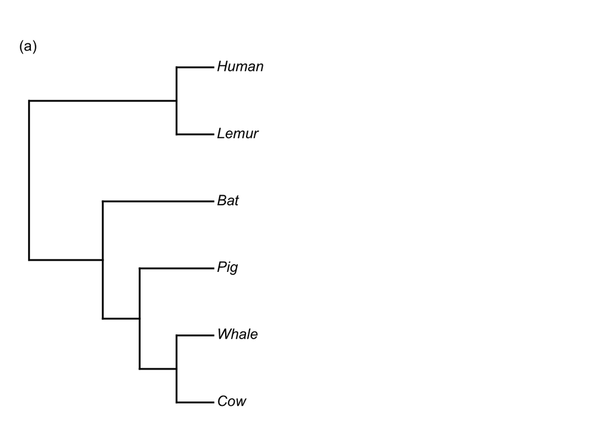

```r
par(mfrow=c(1,2))
plotTree(pr.clade,ftype="i",mar=c(1.1,1.1,3.1,1.1),
cex=1.1)
mtext("(a)",line=0,adj=0)
```

```r
#you can also do it interactivelly!!!s
anolis.pruned<-collapseTree(vert.tree)
```

```
## Click on the nodes that you would like to collapse...
```

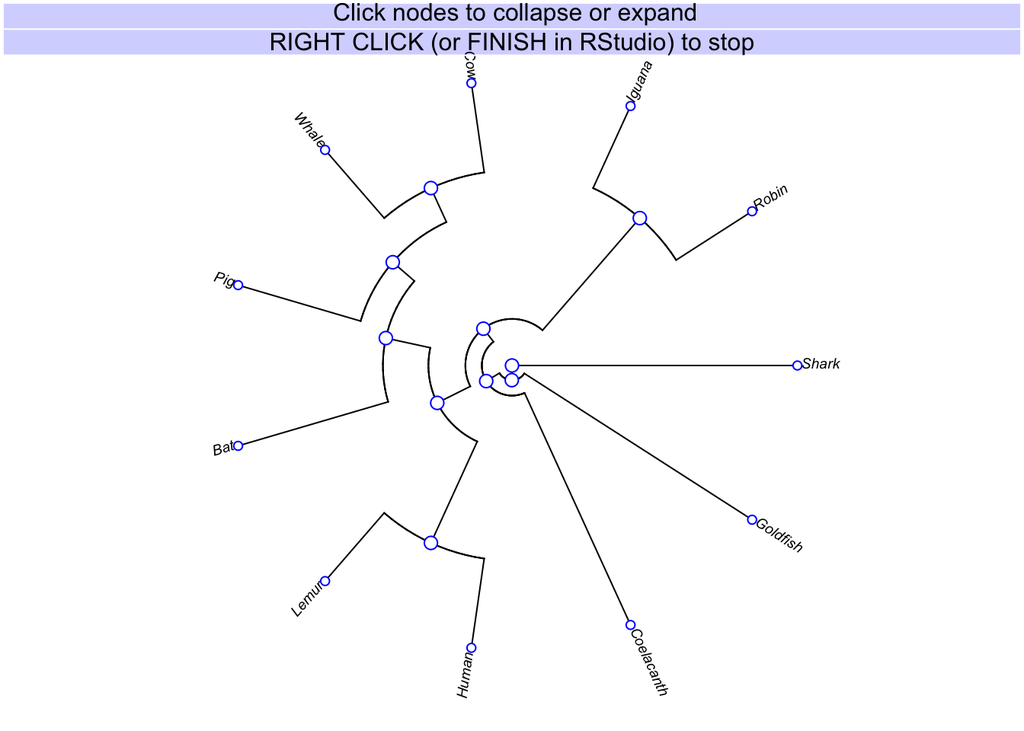

```r
#We can also store multiple trees in an object:
vert.trees<-c(vert.tree,vert.noPR,pr.clade,
pr.tree)
print(vert.trees,details=TRUE)
```

```
## 4 phylogenetic trees
## tree 1 : 11 tips
## tree 2 : 6 tips
## tree 3 : 6 tips
## tree 4 : 5 tips
```

### 1.9 Managing trees and Comparative Data - Primates

“Throughout this book, we’ll often be called upon to manage not only phylogenies but also comparative phenotypic trait data for species. To see an example of how to do this with real data, let’s use two different data files from the book webpage: anole.data.csv and ecomorph.csv (Mahler et al. 2010). We’ll combine the data of these files with the phylogeny from our Anolis tree file (Anolis.tre) that we read into R earlier in the chapter.” I will do it with my data

#### Preraring the data

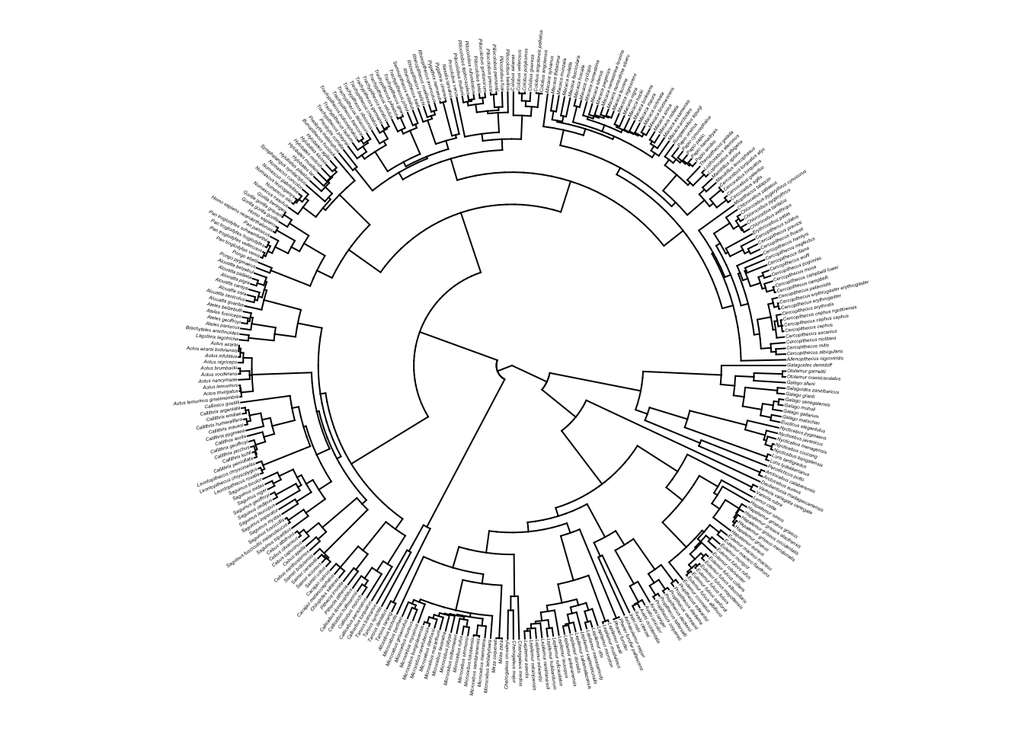

```r
primate_tree <- read.nexus("primates_data/consensusTree_10kTrees_Primates_Version3.nex")
plotTree(primate_tree,type="fan",fsize=0.2,lwd=1,ftype="i")
```

```r
primate_data <- read_csv("primates_data/primates_data_isler_vanschaik.csv")
head(primate_data)
```

```
## # A tibble: 6 × 25
##   Group    `Species number` Genus_species     Allonursing Communal nesting, ba…¹
##   <chr>               <dbl> <chr>                   <dbl>                  <dbl>
## 1 Primates              290 Colobus_guereza             0                      1
## 2 Primates              291 Colobus_polykomos           0                      1
## 3 Primates              251 Callithrix_pygma…           0                      1
## 4 Primates              249 Callithrix_jacch…           0                      1
## 5 Primates              250 Callithrix_penic…           0                      1
## 6 Primates              248 Callithrix_argen…           0                      1
## # ℹ abbreviated name: ¹`Communal nesting, babysitting, retrieval`
## # ℹ 20 more variables: Protection <dbl>, provisioning_Male <dbl>,
## #   provisioning_others <dbl>, carryng_Male <dbl>, carrying_others <dbl>,
## #   PC1 <dbl>, PC2 <dbl>, `Provisioning mothers` <lgl>, Gregariousness <dbl>,
## #   Diet <dbl>, Activity <dbl>, Substrate <dbl>, `Body mass [g]` <dbl>,
## #   `Brain size [g or cc]` <dbl>, `Fertility [offspring per year]` <dbl>,
## #   `Gestation length [d]` <dbl>, `Weaning age [d]` <dbl>, …
```

```r
#Change way the species name is written
#primate_data$species <- gsub("_", " ", primate_data$Genus_species)
primate_data$species <- gsub("_", "_", primate_data$Genus_species)
head(primate_data)
```

```
## # A tibble: 6 × 26
##   Group    `Species number` Genus_species     Allonursing Communal nesting, ba…¹
##   <chr>               <dbl> <chr>                   <dbl>                  <dbl>
## 1 Primates              290 Colobus_guereza             0                      1
## 2 Primates              291 Colobus_polykomos           0                      1
## 3 Primates              251 Callithrix_pygma…           0                      1
## 4 Primates              249 Callithrix_jacch…           0                      1
## 5 Primates              250 Callithrix_penic…           0                      1
## 6 Primates              248 Callithrix_argen…           0                      1
## # ℹ abbreviated name: ¹`Communal nesting, babysitting, retrieval`
## # ℹ 21 more variables: Protection <dbl>, provisioning_Male <dbl>,
## #   provisioning_others <dbl>, carryng_Male <dbl>, carrying_others <dbl>,
## #   PC1 <dbl>, PC2 <dbl>, `Provisioning mothers` <lgl>, Gregariousness <dbl>,
## #   Diet <dbl>, Activity <dbl>, Substrate <dbl>, `Body mass [g]` <dbl>,
## #   `Brain size [g or cc]` <dbl>, `Fertility [offspring per year]` <dbl>,
## #   `Gestation length [d]` <dbl>, `Weaning age [d]` <dbl>, …
```

```r
#rebname the columns and select only the columns I want to work with
colnames(primate_data)[colnames(primate_data) == "Maximum lifespan [y]"] <- "maxlongevity_y"
colnames(primate_data)[colnames(primate_data) == "Gregariousness"] <- "gregariousness"
colnames(primate_data)[colnames(primate_data) == "Allonursing"] <- "allonursing"
colnames(primate_data)[colnames(primate_data) == "Communal nesting, babysitting, retrieval"] <- "communal_nesting_babysitting"
colnames(primate_data)[colnames(primate_data) == "Protection"] <- "protection"
colnames(primate_data)[colnames(primate_data) == "Body mass [g]"] <- "body_mass"
colnames(primate_data)[colnames(primate_data) == "Age at first reproduction [y]"] <- "reproduction_age_y"

primate_df <- subset(primate_data, select = c(species,body_mass,maxlongevity_y,reproduction_age_y,gregariousness,allonursing,communal_nesting_babysitting,protection,provisioning_Male,provisioning_others,carryng_Male,carrying_others))
head(primate_df)
```

```
## # A tibble: 6 × 12
##   species body_mass maxlongevity_y reproduction_age_y gregariousness allonursing
##   <chr>       <dbl>          <dbl>              <dbl>          <dbl>       <dbl>
## 1 Colobu…      7506           35.2               4.75              2           0
## 2 Colobu…      8300           33.9               5.5               2           0
## 3 Callit…       110           18.6               1.9               2           0
## 4 Callit…       320           22.8               1.67              2           0
## 5 Callit…       328           15.4              NA                 2           0
## 6 Callit…       345           16.5               1.67              2           0
## # ℹ 6 more variables: communal_nesting_babysitting <dbl>, protection <dbl>,
## #   provisioning_Male <dbl>, provisioning_others <dbl>, carryng_Male <dbl>,
## #   carrying_others <dbl>
```

```r
#primate_df$species
primate_tree$tip.label
```

```
##   [1] "Allenopithecus_nigroviridis"
##   [2] "Cercopithecus_albogularis"
##   [3] "Cercopithecus_ascanius"
##   [4] "Cercopithecus_campbelli"
##   [5] "Cercopithecus_campbelli_lowei"
##   [6] "Cercopithecus_cephus"
##   [7] "Cercopithecus_cephus_cephus"
##   [8] "Cercopithecus_cephus_ngottoensis"
##   [9] "Cercopithecus_diana"
##  [10] "Cercopithecus_erythrogaster"
##  [11] "Cercopithecus_erythrogaster_erythrogaster"
##  [12] "Cercopithecus_erythrotis"
##  [13] "Cercopithecus_hamlyni"
##  [14] "Cercopithecus_lhoesti"
##  [15] "Cercopithecus_mitis"
```

[output cut: 286 more lines]

```r
#Checking if the names in the philogeny exaclty match the ones in the dataset
chk<-name.check(primate_tree,primate_df$species)
chk
```

```
## $tree_not_data
##   [1] "Allenopithecus_nigroviridis"
##   [2] "Allocebus_trichotis"
##   [3] "Alouatta_belzebul"
##   [4] "Alouatta_caraya"
##   [5] "Alouatta_guariba"
##   [6] "Alouatta_palliata"
##   [7] "Alouatta_pigra"
##   [8] "Alouatta_sara"
##   [9] "Alouatta_seniculus"
##  [10] "Aotus_azarai"
##  [11] "Aotus_azarai_boliviensis"
##  [12] "Aotus_brumbacki"
##  [13] "Aotus_infulatus"
##  [14] "Aotus_lemurinus"
```

[output cut: 290 more lines]

```r
summary(chk)
```

```
## 301 taxa are present in the tree but not the data:
##     Allenopithecus_nigroviridis,
##     Allocebus_trichotis,
##     Alouatta_belzebul,
##     Alouatta_caraya,
##     Alouatta_guariba,
##     Alouatta_palliata,
##     ....
##
## To see complete list of mis-matched taxa, print object.
```